# 06_cosine_get_angle

## 06_cosine_get_angle

#### Question

1. A right triangle has an angle measure $\theta$. The adjacent leg’s length is 34 meters, and the hypotenuse’s length is 44 meters. What is the angle measure $\theta$ in radians?

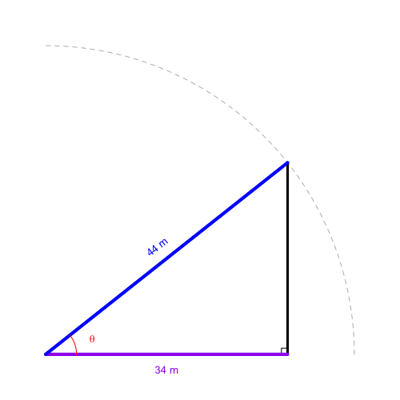

   Please round your answer to the nearest hundredth of a radian.

#### Question

2. A right triangle has an angle measure $\theta$. The adjacent leg’s length is 54 meters, and the hypotenuse’s length is 91 meters. What is the angle measure $\theta$ in radians?

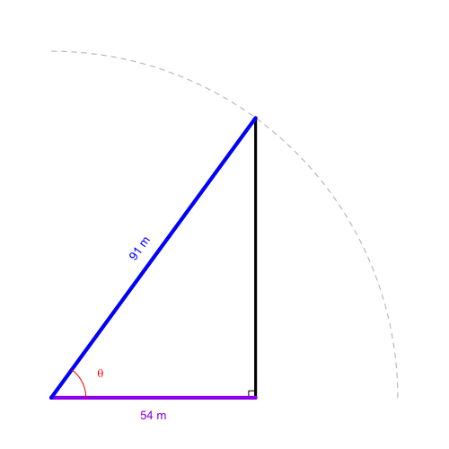

   Please round your answer to the nearest hundredth of a radian.

#### Question

3. A right triangle has an angle measure $\theta$. The adjacent leg’s length is 73 meters, and the hypotenuse’s length is 90 meters. What is the angle measure $\theta$ in radians?

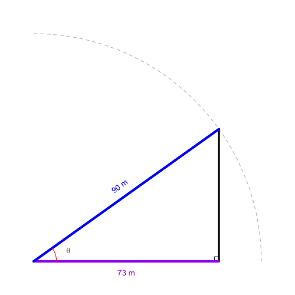

   Please round your answer to the nearest hundredth of a radian.

#### Question

4. A right triangle has an angle measure $\theta$. The adjacent leg’s length is 22 meters, and the hypotenuse’s length is 27 meters. What is the angle measure $\theta$ in radians?

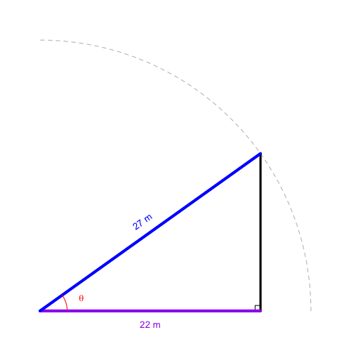

   Please round your answer to the nearest hundredth of a radian.

#### Question

5. A right triangle has an angle measure $\theta$. The adjacent leg’s length is 23 meters, and the hypotenuse’s length is 45 meters. What is the angle measure $\theta$ in radians?

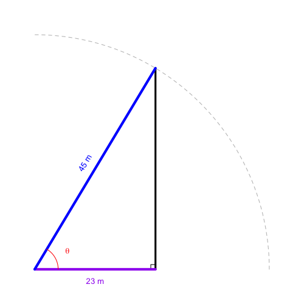

   Please round your answer to the nearest hundredth of a radian.

#### Question

6. A right triangle has an angle measure $\theta$. The adjacent leg’s length is 25 meters, and the hypotenuse’s length is 55 meters. What is the angle measure $\theta$ in radians?

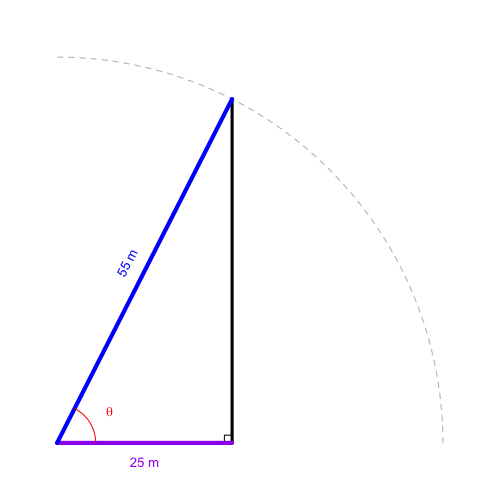

   Please round your answer to the nearest hundredth of a radian.

#### Question

7. A right triangle has an angle measure $\theta$. The adjacent leg’s length is 48 meters, and the hypotenuse’s length is 98 meters. What is the angle measure $\theta$ in radians?

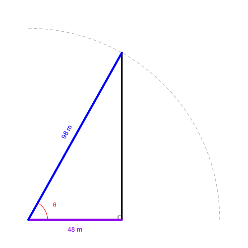

   Please round your answer to the nearest hundredth of a radian.

#### Question

8. A right triangle has an angle measure $\theta$. The adjacent leg’s length is 57 meters, and the hypotenuse’s length is 80 meters. What is the angle measure $\theta$ in radians?

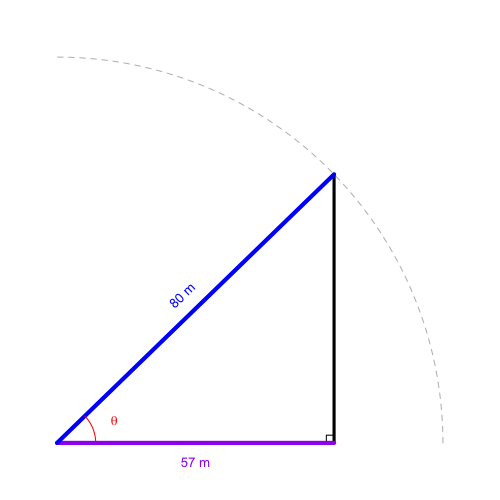

   Please round your answer to the nearest hundredth of a radian.